# Assignment1

```python
import pandas as pd
data = pd.read_csv('Coin_Taps_Sept4_Sept9.csv')
```

```python
#Question 1
#         a)
#Create new dataframe for each team and their stats
team_stats = pd.DataFrame(columns=['team','avg','stdev','zone6percentage'])

#Create an array for of all the teams
teams = data.team.unique()

for i in range(len(teams)):
    #data subset for each team
    teamdata=data[data.team==teams[i]]
    #compute stats for each team
    avg=teamdata.zone.mean()
    stdev=teamdata.zone.std()
    zone6percentage=len(teamdata[teamdata.zone==6])/len(teamdata)

    #record stats in the dataframe
    team_stats.loc[i]=[teams[i],avg,stdev,zone6percentage]


#display stats for the top 15 players
team_stats.sort_values(by=['zone6percentage'],ascending=False)[0:15]
```

|  | team | avg | stdev | zone6percentage |
| --- | --- | --- | --- | --- |
| 0 | Black_Knights | 6.070352 | 2.612146 | 0.236181 |
| 6 | Team_Alpha | 5.731343 | 2.593735 | 0.233831 |
| 1 | Originals | 5.720000 | 2.770990 | 0.200000 |
| 22 | QED | 5.733333 | 1.981838 | 0.200000 |
| 10 | Team_Newton | 6.463576 | 2.851374 | 0.192053 |
| 13 | PennyPinchers2 | 5.969849 | 2.707844 | 0.190955 |
| 11 | PENNY_LOAN | 5.766234 | 2.320109 | 0.181818 |
| 14 | BNS | 5.586667 | 2.512216 | 0.180000 |
| 19 | ThePennyPinchers | 5.913333 | 2.659507 | 0.180000 |
| 15 | Seinfeld | 5.642384 | 2.461285 | 0.178808 |
| 5 | Dosa_Bros_TM | 6.608911 | 2.805559 | 0.168317 |
| 18 | Munkee | 5.564356 | 2.142036 | 0.168317 |
| 21 | CashMoneyYaHur | 5.980000 | 2.550421 | 0.150000 |
| 12 | RainbowMonkeys | 5.493333 | 2.529681 | 0.146667 |
| 7 | CountingIsHard | 5.868421 | 2.825345 | 0.138158 |

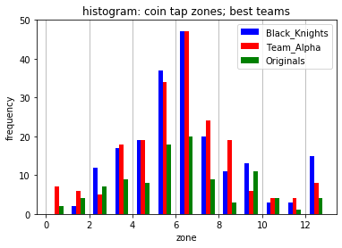

```python
#Question 1
#         b)
import pandas as pd
data = pd.read_csv('Coin_Taps_Sept4_Sept9.csv')
%matplotlib inline
import matplotlib.pyplot as plt


#make a list of zones for the top 3 teams arranged by zone 6 percentage
team1=data.zone[data.team=='Black_Knights'].values.tolist()
team2=data.zone[data.team=='Team_Alpha'].values.tolist()
team3=data.zone[data.team=='Originals'].values.tolist()

#histogram of top 3 teams
plt.hist([team1,team2,team3],bins=[i for i in range(14)], rwidth=0.6, label=['Black_Knights','Team_Alpha', 'Originals'],color=['blue','red','green'])
plt.title('histogram: coin tap zones; best teams')
plt.xlabel('zone')
plt.ylabel('frequency')
plt.ylim(0,50)
plt.grid(axis='x')
plt.legend(loc='upper right');
```

Question 1 c)

Originals were a very accurate team because they had a high frequency in zones 5 and 6 and a bit lower frequency for all other zones

Question 1 d)

Black_Knights were a very precise team because they tended to either have a high frequency in a zone or very low frequency in a zone

```python
#Question 1
#         e)

#create the dataframe
classes_totals=pd.DataFrame(columns=['Class','Total'])
#create array of classes
classes=data.date.unique()

for i in range(len(classes)):

    classdata=data[data.date==classes[i]]
    #calculate the total number attempts per class
    total=len(classdata[classdata.date==classes[i]])
    #record to dataframe
    classes_totals.loc[i]=[classes[i],total]

    #Display the classes
classes_totals.sort_values(by=['Total'],ascending=False)[0:2]
```

|  | Class | Total |
| --- | --- | --- |
| 0 | 09-Sep | 1603 |
| 1 | 04-Sep | 1587 |

Proportion was 1603:1587 with 09-Sep having 16 more attempts.

```python
#Question 1
#         f)

#create the dataframe
classes_totals=pd.DataFrame(columns=['Class','Total','avg','zone6percentage'])
#create array of classes
classes=data.date.unique()

for i in range(len(classes)):

    classdata=data[data.date==classes[i]]
    #calculate the total number attempts per class
    total=len(classdata[classdata.date==classes[i]])
    #calculate avg zone for each class
    avg=classdata.zone.mean()
    #calculate the zone6percentage for each class
    zone6percentage=len(classdata[classdata.zone==6])/len(classdata)
    #record to dataframe
    classes_totals.loc[i]=[classes[i],total,avg,zone6percentage]

    #Display the classes
classes_totals.sort_values(by=['Total'],ascending=False)[0:2]
```

|  | Class | Total | avg | zone6percentage |
| --- | --- | --- | --- | --- |
| 0 | 09-Sep | 1603 | 5.791641 | 0.174049 |
| 1 | 04-Sep | 1587 | 6.335854 | 0.148708 |

The September 9th class was best because they had a better zone 6 percentage as well as a zone average closest to 6.

```python
#Question 2
#         a)
#Create dataframe
zone_stats=pd.DataFrame(columns=['zone','total'])

#create array of all zones
zones=data.zone.unique()

for i in range(len(zones)):
    #make subset of the data for each zone
    zonedata=data[data.zone==zones[i]]

    #compute the totals for each zone
    zonetotal=len(zonedata.zone==zones[i])
    #record to dataframe
    zone_stats.loc[i]=[zones[i],zonetotal]

zone_stats.sort_values(by=['zone'],ascending=True)[0:12]
```

|  | zone | total |
| --- | --- | --- |
| 10 | 0 | 43 |
| 8 | 1 | 74 |
| 6 | 2 | 139 |
| 0 | 3 | 263 |
| 2 | 4 | 385 |
| 4 | 5 | 529 |
| 3 | 6 | 515 |
| 7 | 7 | 362 |
| 5 | 8 | 290 |
| 9 | 9 | 205 |
| 12 | 10 | 142 |
| 11 | 11 | 112 |

```python
#Question 2
#         b)
#Create dataframe
team_stats=pd.DataFrame(columns=['teams'])

#create array of all teams
teams=data.team.unique()

for i in range(len(teams)):
    #make subset of the data for each team
    teamdata=data[data.team==teams[i]]

    #record to dataframe
    team_stats.loc[i]=[teams[i]]

team_stats.sort_values(by=['teams'],ascending=True)[0:50]
```

|  | teams |
| --- | --- |
| 14 | BNS |
| 2 | Backyardigans |
| 17 | BigPennyEnergy |
| 0 | Black_Knights |
| 21 | CashMoneyYaHur |
| 7 | CountingIsHard |
| 5 | Dosa_Bros_TM |
| 16 | Dunkee |
| 8 | KMP |
| 18 | Munkee |
| 1 | Originals |
| 11 | PENNY_LOAN |
| 13 | PennyPinchers2 |
| 20 | Purple_Cobras |
| 22 | QED |
| 12 | RainbowMonkeys |
| 9 | Red_tiles |
| 15 | Seinfeld |
| 3 | Tall_Boys |
| 6 | Team_Alpha |
| 10 | Team_Newton |
| 19 | ThePennyPinchers |
| 4 | Whatever |

19 out of the 23 teams do not contain the substrings "Penny" or "PENNY". Therefore the probability of selecting a team without any of the substrings in it's name can be represented fractionally by (19/23).

```python
player_stats=pd.DataFrame(columns=['player','zone6total'])

#create an array of all players (names)
players=data.name.unique()
#create array of all math dudes
mathDudes=['Euler','Hilbert','Euclid','Ramanujan','Bernoulli','Fisher']
for i in range(len(mathDudes)):

    #make a subset of the data for each math dude
    playerdata=data[data.name==mathDudes[i]]

    #compute stats for each math dude

    zone6total=len(playerdata[playerdata.zone==6])

    #record stats in the dataframe
    player_stats.loc[i]=[mathGuys[i],zone6total]

#display stats for all math dudes
player_stats.sort_values(by=['zone6total'],ascending=False)[0:70]
```

|  | player | zone6total |
| --- | --- | --- |
| 0 | Euler | 13 |
| 1 | Hilbert | 9 |
| 2 | Euclid | 6 |
| 3 | Ramanujan | 6 |
| 4 | Bernoulli | 3 |
| 5 | Fisher | 1 |

The mathematicians scored in zone6, 38 times. There were 3190 taps made in total. Therefore the probability of the selected coin tap being a zone6 shot by a famous mathematician can be represented fractionally by (38/3190)